# Uso del paquete `dplyr`

- Mostrar todo el código
- Ocultar todo el código
- Ver el código fuente

Autor/a

Carlos Lesmes

Fecha de publicación

19 de marzo de 2026

# 1 Paquete `dplyr`

Activamos los paquetes con `library()`después de instalados con la función `install.packages()` en la consola. Recomiendo que instalen el metapaquete `tidyverse`que instala varios paquetes muy útiles en el análisis de datos, entre estos instala `dplyr`.

**Código**

```r
library(dplyr)
# suppressPackageStartupMessages(library(dplyr))
library(nycflights23)
```

Algunos paquetes, los más recientes, traen viñetas con documentación de ayuda sobre el paquete, para ver las viñetas del paquete `dplyr` vaya a la lengüeta `Packages` y dé clic en el paquete `dplyr` y vaya a `user guides, package vignettes and other documentation`. Inicalmente vea `dplyr::base` `HTML`. Se recomienda estudiarlas en orden. Obtenga información sobre las viñetas escribiendo en la consola `vignettes(package='dplyr')` y para ver la viñeta `base` escriba `vignettes('base',package='dplyr)` . El paquete `nycflights23` contiene el dataframe `flights` y lo convertimos a `tibble`: un dataframe con más propiedades.

**Código**

```r
flights <- as_tibble(flights)
head(flights)
```

| year | month | day | dep_time | sched_dep_time | dep_delay | arr_time | sched_arr_time | arr_delay | carrier | flight | tailnum | origin | dest | air_time | distance | hour | minute | time_hour |
| --- | --- | --- | --- | --- | --- | --- | --- | --- | --- | --- | --- | --- | --- | --- | --- | --- | --- | --- |
| 2023 | 1 | 1 | 1 | 2038 | 203 | 328 | 3 | 205 | UA | 628 | N25201 | EWR | SMF | 367 | 2500 | 20 | 38 | 2023-01-01 20:00:00 |
| 2023 | 1 | 1 | 18 | 2300 | 78 | 228 | 135 | 53 | DL | 393 | N830DN | JFK | ATL | 108 | 760 | 23 | 0 | 2023-01-01 23:00:00 |
| 2023 | 1 | 1 | 31 | 2344 | 47 | 500 | 426 | 34 | B6 | 371 | N807JB | JFK | BQN | 190 | 1576 | 23 | 44 | 2023-01-01 23:00:00 |
| 2023 | 1 | 1 | 33 | 2140 | 173 | 238 | 2352 | 166 | B6 | 1053 | N265JB | JFK | CHS | 108 | 636 | 21 | 40 | 2023-01-01 21:00:00 |
| 2023 | 1 | 1 | 36 | 2048 | 228 | 223 | 2252 | 211 | UA | 219 | N17730 | EWR | DTW | 80 | 488 | 20 | 48 | 2023-01-01 20:00:00 |
| 2023 | 1 | 1 | 503 | 500 | 3 | 808 | 815 | -7 | AA | 499 | N925AN | EWR | MIA | 154 | 1085 | 5 | 0 | 2023-01-01 05:00:00 |

Estudiaremos las funciones básicas más útiles del paquete `dplyr` para la manipulación de un tibble o dataframe.

1. La función `filter()` extrae las observaciones (filas) de un `dataframe` o `tibble`.
2. `select()` selecciona columnas de un `tibble`.
3. La función `arrange()` reordena las filas de un `dataframe`.
4. `mutate()` crea nuevas funciones a partir de las ya existentes.
5. `summarize()` colapsa un `tibble` hacía abajo para obtener resúmenes, va generalmente, acompañado de la función `group_by()`.

Recuerde que:

1. El primer argumento de las funciones es un `dataframe`.
2. Los siguientes argumentos describen qué hacer con el `dataframe` usando los nombres de las variables **sin** comillas.
3. El resultado es un `dataframe`.

Usaremos el archivo `flights`. Una de los primeros pasos es escribir en la consola `help(flights)` y leer en qué consiste cada una de las variables. Segundo, veamos como es su estructura.

**Código**

```r
str(flights)
```

```
tibble [435,352 × 19] (S3: tbl_df/tbl/data.frame)
 $ year          : int [1:435352] 2023 2023 2023 2023 2023 2023 2023 2023 2023 2023 ...
 $ month         : int [1:435352] 1 1 1 1 1 1 1 1 1 1 ...
 $ day           : int [1:435352] 1 1 1 1 1 1 1 1 1 1 ...
 $ dep_time      : int [1:435352] 1 18 31 33 36 503 520 524 537 547 ...
 $ sched_dep_time: int [1:435352] 2038 2300 2344 2140 2048 500 510 530 520 545 ...
 $ dep_delay     : num [1:435352] 203 78 47 173 228 3 10 -6 17 2 ...
 $ arr_time      : int [1:435352] 328 228 500 238 223 808 948 645 926 845 ...
 $ sched_arr_time: int [1:435352] 3 135 426 2352 2252 815 949 710 818 852 ...
 $ arr_delay     : num [1:435352] 205 53 34 166 211 -7 -1 -25 68 -7 ...
 $ carrier       : chr [1:435352] "UA" "DL" "B6" "B6" ...
 $ flight        : int [1:435352] 628 393 371 1053 219 499 996 981 206 225 ...
 $ tailnum       : chr [1:435352] "N25201" "N830DN" "N807JB" "N265JB" ...
 $ origin        : chr [1:435352] "EWR" "JFK" "JFK" "JFK" ...
 $ dest          : chr [1:435352] "SMF" "ATL" "BQN" "CHS" ...
 $ air_time      : num [1:435352] 367 108 190 108 80 154 192 119 258 157 ...
 $ distance      : num [1:435352] 2500 760 1576 636 488 ...
 $ hour          : num [1:435352] 20 23 23 21 20 5 5 5 5 5 ...
 $ minute        : num [1:435352] 38 0 44 40 48 0 10 30 20 45 ...
 $ time_hour     : POSIXct[1:435352], format: "2023-01-01 20:00:00" "2023-01-01 23:00:00" ...
```

Los nombres de las variables y sus dimensiones:

**Código**

```r
names(flights)
```

```
 [1] "year"           "month"          "day"            "dep_time"
 [5] "sched_dep_time" "dep_delay"      "arr_time"       "sched_arr_time"
 [9] "arr_delay"      "carrier"        "flight"         "tailnum"
[13] "origin"         "dest"           "air_time"       "distance"
[17] "hour"           "minute"         "time_hour"
```

**Código**

```r
dim(flights)
```

```
[1] 435352     19
```

**Código**

```r
nrow(flights)
```

```
[1] 435352
```

**Código**

```r
ncol(flights)
```

```
[1] 19
```

# 2 Operadores Booleanos (lógicos)

En ocasiones se necesita utilizar combinaciones de los operadores “y”, “o”, “no”. En R `&` es y, `|` es o y `!` es no.

# 3 Funciones clave

## 3.1 La función `filter()`

La función selecciona las filas con la condición deseada. Selecionemos los viajes de diciembre:

**Código**

```r
dic <- filter(flights, month == 12)
head(dic)
```

| year | month | day | dep_time | sched_dep_time | dep_delay | arr_time | sched_arr_time | arr_delay | carrier | flight | tailnum | origin | dest | air_time | distance | hour | minute | time_hour |
| --- | --- | --- | --- | --- | --- | --- | --- | --- | --- | --- | --- | --- | --- | --- | --- | --- | --- | --- |
| 2023 | 12 | 1 | 506 | 509 | -3 | 807 | 823 | -16 | AA | 411 | N326RP | EWR | MIA | 149 | 1085 | 5 | 9 | 2023-12-01 05:00:00 |
| 2023 | 12 | 1 | 512 | 516 | -4 | 800 | 815 | -15 | NK | 19 | N524NK | EWR | MCO | 136 | 937 | 5 | 16 | 2023-12-01 05:00:00 |
| 2023 | 12 | 1 | 520 | 525 | -5 | 800 | 820 | -20 | B6 | 41 | N535JB | EWR | PBI | 138 | 1023 | 5 | 25 | 2023-12-01 05:00:00 |
| 2023 | 12 | 1 | 525 | 530 | -5 | 900 | 859 | 1 | NK | 347 | N635NK | EWR | PHX | 317 | 2133 | 5 | 30 | 2023-12-01 05:00:00 |
| 2023 | 12 | 1 | 536 | 530 | 6 | 825 | 844 | -19 | AA | 239 | N319TE | JFK | MIA | 151 | 1089 | 5 | 30 | 2023-12-01 05:00:00 |
| 2023 | 12 | 1 | 540 | 545 | -5 | 832 | 844 | -12 | UA | 166 | N68817 | EWR | IAH | 210 | 1400 | 5 | 45 | 2023-12-01 05:00:00 |

Seleccionemos los viajes del 31 de diciembre

**Código**

```r
dic31 <- filter(flights, month == 12, day == 31)
head(dic31)
```

| year | month | day | dep_time | sched_dep_time | dep_delay | arr_time | sched_arr_time | arr_delay | carrier | flight | tailnum | origin | dest | air_time | distance | hour | minute | time_hour |
| --- | --- | --- | --- | --- | --- | --- | --- | --- | --- | --- | --- | --- | --- | --- | --- | --- | --- | --- |
| 2023 | 12 | 31 | 107 | 2250 | 137 | 355 | 203 | 112 | F9 | 1175 | N310FR | LGA | DFW | 195 | 1389 | 22 | 50 | 2023-12-31 22:00:00 |
| 2023 | 12 | 31 | 459 | 510 | -11 | 744 | 804 | -20 | B6 | 525 | N641JB | EWR | MCO | 132 | 937 | 5 | 10 | 2023-12-31 05:00:00 |
| 2023 | 12 | 31 | 459 | 501 | -2 | 955 | 942 | 13 | B6 | 570 | N603JB | EWR | SJU | 208 | 1608 | 5 | 1 | 2023-12-31 05:00:00 |
| 2023 | 12 | 31 | 509 | 508 | 1 | 754 | 823 | -29 | AA | 411 | N843NN | EWR | MIA | 142 | 1085 | 5 | 8 | 2023-12-31 05:00:00 |
| 2023 | 12 | 31 | 509 | 510 | -1 | 744 | 802 | -18 | B6 | 207 | N623JB | JFK | MCO | 130 | 944 | 5 | 10 | 2023-12-31 05:00:00 |
| 2023 | 12 | 31 | 510 | 510 | 0 | 748 | 825 | -37 | B6 | 488 | N961JT | EWR | LAX | 314 | 2454 | 5 | 10 | 2023-12-31 05:00:00 |

Seleccionemos los viajes de noviembre y diciembre

**Código**

```r
nov_dic <- filter(flights, month == 11 | month ==12)
head(nov_dic)
```

| year | month | day | dep_time | sched_dep_time | dep_delay | arr_time | sched_arr_time | arr_delay | carrier | flight | tailnum | origin | dest | air_time | distance | hour | minute | time_hour |
| --- | --- | --- | --- | --- | --- | --- | --- | --- | --- | --- | --- | --- | --- | --- | --- | --- | --- | --- |
| 2023 | 11 | 1 | 2 | 2340 | 22 | 57 | 54 | 3 | B6 | 573 | N3085J | JFK | BOS | 40 | 187 | 23 | 40 | 2023-11-01 23:00:00 |
| 2023 | 11 | 1 | 8 | 2215 | 113 | 116 | 2349 | 87 | OO | 1179 | N247SY | JFK | BOS | 42 | 187 | 22 | 15 | 2023-11-01 22:00:00 |
| 2023 | 11 | 1 | 508 | 510 | -2 | 814 | 818 | -4 | AA | 405 | N328RR | EWR | MIA | 160 | 1085 | 5 | 10 | 2023-11-01 05:00:00 |
| 2023 | 11 | 1 | 523 | 530 | -7 | 816 | 827 | -11 | UA | 176 | N37514 | EWR | IAH | 206 | 1400 | 5 | 30 | 2023-11-01 05:00:00 |
| 2023 | 11 | 1 | 541 | 545 | -4 | 736 | 740 | -4 | NK | 325 | N633NK | LGA | MYR | 97 | 563 | 5 | 45 | 2023-11-01 05:00:00 |
| 2023 | 11 | 1 | 544 | 545 | -1 | 846 | 853 | -7 | AA | 47 | N117AN | JFK | LAX | 338 | 2475 | 5 | 45 | 2023-11-01 05:00:00 |

**Código**

```r
tail(nov_dic)
```

| year | month | day | dep_time | sched_dep_time | dep_delay | arr_time | sched_arr_time | arr_delay | carrier | flight | tailnum | origin | dest | air_time | distance | hour | minute | time_hour |
| --- | --- | --- | --- | --- | --- | --- | --- | --- | --- | --- | --- | --- | --- | --- | --- | --- | --- | --- |
| 2023 | 12 | 31 | 2207 | 2200 | 7 | 58 | 115 | -17 | NK | 1131 | N712NK | EWR | LAX | 323 | 2454 | 22 | 0 | 2023-12-31 22:00:00 |
| 2023 | 12 | 31 | 2218 | 2224 | -6 | 304 | 325 | -21 | NK | 364 | N647NK | EWR | SJU | 203 | 1608 | 22 | 24 | 2023-12-31 22:00:00 |
| 2023 | 12 | 31 | 2243 | 2150 | 53 | 143 | 56 | 47 | B6 | 367 | N566JB | JFK | PBI | 149 | 1028 | 21 | 50 | 2023-12-31 21:00:00 |
| 2023 | 12 | 31 | 2248 | 2259 | -11 | 338 | 350 | -12 | B6 | 283 | N793JB | JFK | PSE | 207 | 1617 | 22 | 59 | 2023-12-31 22:00:00 |
| 2023 | 12 | 31 | 2326 | 2325 | 1 | 412 | 405 | 7 | B6 | 313 | N807JB | JFK | BQN | 199 | 1576 | 23 | 25 | 2023-12-31 23:00:00 |
| 2023 | 12 | 31 | 2345 | 2255 | 50 | 425 | 347 | 38 | B6 | 126 | N994JL | JFK | SJU | 201 | 1598 | 22 | 55 | 2023-12-31 22:00:00 |

la función `between()` es útil si fueran varios meses:

**Código**

```r
sep_dic <- filter(flights, between(month, 9, 12))
head(sep_dic)
```

| year | month | day | dep_time | sched_dep_time | dep_delay | arr_time | sched_arr_time | arr_delay | carrier | flight | tailnum | origin | dest | air_time | distance | hour | minute | time_hour |
| --- | --- | --- | --- | --- | --- | --- | --- | --- | --- | --- | --- | --- | --- | --- | --- | --- | --- | --- |
| 2023 | 9 | 1 | 12 | 2236 | 96 | 120 | 2359 | 81 | UA | 458 | N485UA | EWR | BUF | 46 | 282 | 22 | 36 | 2023-09-01 22:00:00 |
| 2023 | 9 | 1 | 27 | 2210 | 137 | 225 | 33 | 112 | NK | 253 | N967NK | EWR | LAS | 274 | 2227 | 22 | 10 | 2023-09-01 22:00:00 |
| 2023 | 9 | 1 | 38 | 2259 | 99 | 425 | 258 | 87 | B6 | 274 | N591JB | JFK | PSE | 199 | 1617 | 22 | 59 | 2023-09-01 22:00:00 |
| 2023 | 9 | 1 | 105 | 1916 | 349 | 443 | 2313 | 330 | B6 | 448 | N827JB | EWR | SJU | 190 | 1608 | 19 | 16 | 2023-09-01 19:00:00 |
| 2023 | 9 | 1 | 113 | 2000 | 313 | 222 | 2139 | 283 | B6 | 931 | N281JB | JFK | BUF | 49 | 301 | 20 | 0 | 2023-09-01 20:00:00 |
| 2023 | 9 | 1 | 457 | 500 | -3 | 803 | 812 | -9 | NK | 268 | N904NK | EWR | OAK | 343 | 2555 | 5 | 0 | 2023-09-01 05:00:00 |

**Código**

```r
tail(sep_dic)
```

| year | month | day | dep_time | sched_dep_time | dep_delay | arr_time | sched_arr_time | arr_delay | carrier | flight | tailnum | origin | dest | air_time | distance | hour | minute | time_hour |
| --- | --- | --- | --- | --- | --- | --- | --- | --- | --- | --- | --- | --- | --- | --- | --- | --- | --- | --- |
| 2023 | 12 | 31 | 2207 | 2200 | 7 | 58 | 115 | -17 | NK | 1131 | N712NK | EWR | LAX | 323 | 2454 | 22 | 0 | 2023-12-31 22:00:00 |
| 2023 | 12 | 31 | 2218 | 2224 | -6 | 304 | 325 | -21 | NK | 364 | N647NK | EWR | SJU | 203 | 1608 | 22 | 24 | 2023-12-31 22:00:00 |
| 2023 | 12 | 31 | 2243 | 2150 | 53 | 143 | 56 | 47 | B6 | 367 | N566JB | JFK | PBI | 149 | 1028 | 21 | 50 | 2023-12-31 21:00:00 |
| 2023 | 12 | 31 | 2248 | 2259 | -11 | 338 | 350 | -12 | B6 | 283 | N793JB | JFK | PSE | 207 | 1617 | 22 | 59 | 2023-12-31 22:00:00 |
| 2023 | 12 | 31 | 2326 | 2325 | 1 | 412 | 405 | 7 | B6 | 313 | N807JB | JFK | BQN | 199 | 1576 | 23 | 25 | 2023-12-31 23:00:00 |
| 2023 | 12 | 31 | 2345 | 2255 | 50 | 425 | 347 | 38 | B6 | 126 | N994JL | JFK | SJU | 201 | 1598 | 22 | 55 | 2023-12-31 22:00:00 |

¿Qué `dataframe` representa `primeros_ago_nov` en el siguiente código?

**Código**

```r
primeros_ago_nov <- filter(flights, between(month, 8, 11) & day == 1)
head(primeros_ago_nov, 3)
```

| year | month | day | dep_time | sched_dep_time | dep_delay | arr_time | sched_arr_time | arr_delay | carrier | flight | tailnum | origin | dest | air_time | distance | hour | minute | time_hour |
| --- | --- | --- | --- | --- | --- | --- | --- | --- | --- | --- | --- | --- | --- | --- | --- | --- | --- | --- |
| 2023 | 8 | 1 | 3 | 2035 | 208 | 224 | 2330 | 174 | UA | 219 | N17294 | EWR | AUS | 182 | 1504 | 20 | 35 | 2023-08-01 20:00:00 |
| 2023 | 8 | 1 | 38 | 2255 | 103 | 245 | 118 | 87 | F9 | 451 | N721FR | LGA | ATL | 104 | 762 | 22 | 55 | 2023-08-01 22:00:00 |
| 2023 | 8 | 1 | 458 | 501 | -3 | 904 | 843 | 21 | B6 | 730 | N954JB | JFK | BQN | 218 | 1576 | 5 | 1 | 2023-08-01 05:00:00 |

**Código**

```r
tail(primeros_ago_nov, 3)
```

| year | month | day | dep_time | sched_dep_time | dep_delay | arr_time | sched_arr_time | arr_delay | carrier | flight | tailnum | origin | dest | air_time | distance | hour | minute | time_hour |
| --- | --- | --- | --- | --- | --- | --- | --- | --- | --- | --- | --- | --- | --- | --- | --- | --- | --- | --- |
| 2023 | 11 | 1 | 2337 | 2159 | 98 | 226 | 58 | 88 | NK | 490 | N638NK | EWR | MCO | 146 | 937 | 21 | 59 | 2023-11-01 21:00:00 |
| 2023 | 11 | 1 | 2345 | 2229 | 76 | 104 | 2359 | 65 | B6 | 28 | N306JB | JFK | BUF | 57 | 301 | 22 | 29 | 2023-11-01 22:00:00 |
| 2023 | 11 | 1 | NA | 1415 | NA | NA | 1531 | NA | B6 | 310 | N249JB | LGA | BOS | NA | 184 | 14 | 15 | 2023-11-01 14:00:00 |

## 3.2 `arrange()`

Esta función también selecciona filas pero les cambia el orden. Toma el `dataframe` y un conjunto de columnas y las ordena en forma ascendente, empezando por la primera. Si hay varias columnas, cada columna adicional será usada para *romper* los empates. Se puede ordenar en forma descendente usando la función `desc()`.

**Código**

```r
ord3 <- arrange(flights, year, month, day)
head(ord3)
```

| year | month | day | dep_time | sched_dep_time | dep_delay | arr_time | sched_arr_time | arr_delay | carrier | flight | tailnum | origin | dest | air_time | distance | hour | minute | time_hour |
| --- | --- | --- | --- | --- | --- | --- | --- | --- | --- | --- | --- | --- | --- | --- | --- | --- | --- | --- |
| 2023 | 1 | 1 | 1 | 2038 | 203 | 328 | 3 | 205 | UA | 628 | N25201 | EWR | SMF | 367 | 2500 | 20 | 38 | 2023-01-01 20:00:00 |
| 2023 | 1 | 1 | 18 | 2300 | 78 | 228 | 135 | 53 | DL | 393 | N830DN | JFK | ATL | 108 | 760 | 23 | 0 | 2023-01-01 23:00:00 |
| 2023 | 1 | 1 | 31 | 2344 | 47 | 500 | 426 | 34 | B6 | 371 | N807JB | JFK | BQN | 190 | 1576 | 23 | 44 | 2023-01-01 23:00:00 |
| 2023 | 1 | 1 | 33 | 2140 | 173 | 238 | 2352 | 166 | B6 | 1053 | N265JB | JFK | CHS | 108 | 636 | 21 | 40 | 2023-01-01 21:00:00 |
| 2023 | 1 | 1 | 36 | 2048 | 228 | 223 | 2252 | 211 | UA | 219 | N17730 | EWR | DTW | 80 | 488 | 20 | 48 | 2023-01-01 20:00:00 |
| 2023 | 1 | 1 | 503 | 500 | 3 | 808 | 815 | -7 | AA | 499 | N925AN | EWR | MIA | 154 | 1085 | 5 | 0 | 2023-01-01 05:00:00 |

**Código**

```r
demoras_lleg <- arrange(flights, desc(arr_delay))
head(demoras_lleg,20)
```

| year | month | day | dep_time | sched_dep_time | dep_delay | arr_time | sched_arr_time | arr_delay | carrier | flight | tailnum | origin | dest | air_time | distance | hour | minute | time_hour |
| --- | --- | --- | --- | --- | --- | --- | --- | --- | --- | --- | --- | --- | --- | --- | --- | --- | --- | --- |
| 2023 | 12 | 17 | 1953 | 1340 | 1813 | 2155 | 1543 | 1812 | AA | 645 | N195UW | EWR | CLT | 86 | 529 | 13 | 40 | 2023-12-17 13:00:00 |
| 2023 | 10 | 1 | 1240 | 659 | 1781 | 1407 | 835 | 1772 | AA | 992 | N958NN | EWR | ORD | 102 | 719 | 6 | 59 | 2023-10-01 06:00:00 |
| 2023 | 4 | 25 | 1201 | 659 | 1742 | 1315 | 818 | 1737 | AA | 518 | N808AW | LGA | DCA | 42 | 214 | 6 | 59 | 2023-04-25 06:00:00 |
| 2023 | 2 | 7 | 2045 | 1700 | 1665 | 2352 | 2025 | 1647 | AA | 600 | N967AN | LGA | DFW | 223 | 1389 | 17 | 0 | 2023-02-07 17:00:00 |
| 2023 | 4 | 20 | 926 | 619 | 1627 | 1135 | 822 | 1633 | AA | 322 | N153UW | JFK | CLT | 80 | 541 | 6 | 19 | 2023-04-20 06:00:00 |
| 2023 | 10 | 29 | 856 | 600 | 1616 | 1050 | 805 | 1605 | AA | 215 | N162UW | LGA | CLT | 87 | 544 | 6 | 0 | 2023-10-29 06:00:00 |
| 2023 | 3 | 17 | 2027 | 1830 | 1557 | 2346 | 2139 | 1567 | AA | 897 | N938AN | EWR | DFW | 213 | 1372 | 18 | 30 | 2023-03-17 18:00:00 |
| 2023 | 4 | 30 | 1818 | 1617 | 1561 | 2001 | 1820 | 1541 | AA | 840 | N191UW | JFK | CLT | 82 | 541 | 16 | 17 | 2023-04-30 16:00:00 |
| 2023 | 3 | 29 | 633 | 525 | 1508 | 820 | 700 | 1520 | AA | 913 | N895NN | EWR | ORD | 130 | 719 | 5 | 25 | 2023-03-29 05:00:00 |
| 2023 | 7 | 15 | 1918 | 1954 | 1404 | 42 | 2353 | 1489 | UA | 197 | N75425 | EWR | BQN | 263 | 1585 | 19 | 54 | 2023-07-15 19:00:00 |
| 2023 | 7 | 14 | 1533 | 1600 | 1413 | 1935 | 1849 | 1486 | AA | 818 | N856NN | LGA | DFW | 201 | 1389 | 16 | 0 | 2023-07-14 16:00:00 |
| 2023 | 3 | 19 | 1154 | 1201 | 1433 | 1321 | 1335 | 1426 | AA | 455 | N995AN | EWR | ORD | 112 | 719 | 12 | 1 | 2023-03-19 12:00:00 |
| 2023 | 4 | 4 | 1243 | 1400 | 1363 | 1517 | 1548 | 1409 | OO | 1421 | N208SY | LGA | ORD | 174 | 733 | 14 | 0 | 2023-04-04 14:00:00 |
| 2023 | 9 | 10 | 949 | 1100 | 1369 | 1316 | 1406 | 1390 | AA | 103 | N113AN | JFK | LAX | 344 | 2475 | 11 | 0 | 2023-09-10 11:00:00 |
| 2023 | 7 | 9 | 955 | 1055 | 1380 | 1157 | 1255 | 1382 | G4 | 203 | 211NV | EWR | GRR | 85 | 605 | 10 | 55 | 2023-07-09 10:00:00 |
| 2023 | 10 | 10 | 1742 | 1905 | 1357 | 2002 | 2118 | 1364 | AA | 617 | N935AN | LGA | CLT | 97 | 544 | 19 | 5 | 2023-10-10 19:00:00 |
| 2023 | 7 | 26 | 911 | 1016 | 1375 | 1105 | 1236 | 1349 | AA | 654 | N534UW | EWR | PHX | 268 | 2133 | 10 | 16 | 2023-07-26 10:00:00 |
| 2023 | 7 | 18 | 1439 | 1559 | 1360 | 1717 | 1852 | 1345 | AA | 722 | N922NN | JFK | DFW | 179 | 1391 | 15 | 59 | 2023-07-18 15:00:00 |
| 2023 | 3 | 3 | 1121 | 1300 | 1341 | 1325 | 1502 | 1343 | AA | 639 | N551UW | LGA | CLT | 98 | 544 | 13 | 0 | 2023-03-03 13:00:00 |
| 2023 | 3 | 4 | 650 | 810 | 1360 | 833 | 1013 | 1340 | AA | 993 | N199UW | LGA | CLT | 88 | 544 | 8 | 10 | 2023-03-04 08:00:00 |

**Código**

```r
tail(demoras_lleg,3)
```

| year | month | day | dep_time | sched_dep_time | dep_delay | arr_time | sched_arr_time | arr_delay | carrier | flight | tailnum | origin | dest | air_time | distance | hour | minute | time_hour |
| --- | --- | --- | --- | --- | --- | --- | --- | --- | --- | --- | --- | --- | --- | --- | --- | --- | --- | --- |
| 2023 | 12 | 28 | NA | 2245 | NA | NA | 13 | NA | B6 | 61 | N206JB | JFK | BTV | NA | 266 | 22 | 45 | 2023-12-28 22:00:00 |
| 2023 | 12 | 30 | NA | 2045 | NA | NA | 2230 | NA | MQ | 1000 | N763CC | EWR | ORD | NA | 719 | 20 | 45 | 2023-12-30 20:00:00 |
| 2023 | 12 | 31 | 1559 | 1600 | -1 | 2024 | 1844 | NA | YX | 1075 | N766YX | EWR | ATL | NA | 746 | 16 | 0 | 2023-12-31 16:00:00 |

Note que los datos faltantes `NA` los coloca al final.

## 3.3 `select()`

Esta función selecciona columnas. Generalmente los conjuntos de datos tienen cientos o miles de variables. En este caso el analista selecciona las variables en as que está interesado.

**Código**

```r
tres <- select(flights, year, month, day)
head(tres)
```

| year | month | day |
| --- | --- | --- |
| 2023 | 1 | 1 |
| 2023 | 1 | 1 |
| 2023 | 1 | 1 |
| 2023 | 1 | 1 |
| 2023 | 1 | 1 |
| 2023 | 1 | 1 |

Si son varias las variables a seleccionar use `:`

**Código**

```r
tres1 <- select(flights, year:day)
head(tres1)
```

| year | month | day |
| --- | --- | --- |
| 2023 | 1 | 1 |
| 2023 | 1 | 1 |
| 2023 | 1 | 1 |
| 2023 | 1 | 1 |
| 2023 | 1 | 1 |
| 2023 | 1 | 1 |

Para suprimir algunas variables use `-`

**Código**

```r
sin_ymd <- select(flights, -(year:day))
head(sin_ymd)
```

| dep_time | sched_dep_time | dep_delay | arr_time | sched_arr_time | arr_delay | carrier | flight | tailnum | origin | dest | air_time | distance | hour | minute | time_hour |
| --- | --- | --- | --- | --- | --- | --- | --- | --- | --- | --- | --- | --- | --- | --- | --- |
| 1 | 2038 | 203 | 328 | 3 | 205 | UA | 628 | N25201 | EWR | SMF | 367 | 2500 | 20 | 38 | 2023-01-01 20:00:00 |
| 18 | 2300 | 78 | 228 | 135 | 53 | DL | 393 | N830DN | JFK | ATL | 108 | 760 | 23 | 0 | 2023-01-01 23:00:00 |
| 31 | 2344 | 47 | 500 | 426 | 34 | B6 | 371 | N807JB | JFK | BQN | 190 | 1576 | 23 | 44 | 2023-01-01 23:00:00 |
| 33 | 2140 | 173 | 238 | 2352 | 166 | B6 | 1053 | N265JB | JFK | CHS | 108 | 636 | 21 | 40 | 2023-01-01 21:00:00 |
| 36 | 2048 | 228 | 223 | 2252 | 211 | UA | 219 | N17730 | EWR | DTW | 80 | 488 | 20 | 48 | 2023-01-01 20:00:00 |
| 503 | 500 | 3 | 808 | 815 | -7 | AA | 499 | N925AN | EWR | MIA | 154 | 1085 | 5 | 0 | 2023-01-01 05:00:00 |

Para poner ciertas variables al comienzo:

**Código**

```r
time <- select(flights, time_hour, air_time, everything())
time[1:5,1:5]
```

| time_hour | air_time | year | month | day |
| --- | --- | --- | --- | --- |
| 2023-01-01 20:00:00 | 367 | 2023 | 1 | 1 |
| 2023-01-01 23:00:00 | 108 | 2023 | 1 | 1 |
| 2023-01-01 23:00:00 | 190 | 2023 | 1 | 1 |
| 2023-01-01 21:00:00 | 108 | 2023 | 1 | 1 |
| 2023-01-01 20:00:00 | 80 | 2023 | 1 | 1 |

Hay varias funciones de ayuda *helpers* que se pueden usar dentro de `select()`:

1. `starts_with("abc")` coincide con los nombres que empiezan con “abc”
2. `ends_with("xyz")` coincide con los nombres que terminan con “xyz”
3. `contains("ijk")` coincide con los nombres que contienen “ijk”

Por ejemplo, sacar las variables que terminan con “delay”

**Código**

```r
con_delay <- select(flights,year:day,ends_with("delay"), distance, air_time)
head(con_delay)
```

| year | month | day | dep_delay | arr_delay | distance | air_time |
| --- | --- | --- | --- | --- | --- | --- |
| 2023 | 1 | 1 | 203 | 205 | 2500 | 367 |
| 2023 | 1 | 1 | 78 | 53 | 760 | 108 |
| 2023 | 1 | 1 | 47 | 34 | 1576 | 190 |
| 2023 | 1 | 1 | 173 | 166 | 636 | 108 |
| 2023 | 1 | 1 | 228 | 211 | 488 | 80 |
| 2023 | 1 | 1 | 3 | -7 | 1085 | 154 |

## 3.4 `mutate()`

Para crear nuevas variables

**Código**

```r
horas_aire <- mutate(flights, horas = air_time / 60)
horas_aire[1,]
```

| year | month | day | dep_time | sched_dep_time | dep_delay | arr_time | sched_arr_time | arr_delay | carrier | flight | tailnum | origin | dest | air_time | distance | hour | minute | time_hour | horas |
| --- | --- | --- | --- | --- | --- | --- | --- | --- | --- | --- | --- | --- | --- | --- | --- | --- | --- | --- | --- |
| 2023 | 1 | 1 | 1 | 2038 | 203 | 328 | 3 | 205 | UA | 628 | N25201 | EWR | SMF | 367 | 2500 | 20 | 38 | 2023-01-01 20:00:00 | 6.116667 |

## 3.5 `summarize()`

Encontrar el número de vuelos que llegaron a cada uno de los destinos en 2023:

**Código**

```r
destinos <- group_by(flights,dest)
vuelos_destino <- summarize(destinos,n=n())
head(vuelos_destino)
```

| dest | n |
| --- | --- |
| ABQ | 228 |
| ACK | 916 |
| AGS | 20 |
| ALB | 1581 |
| ANC | 95 |
| ATL | 17570 |

Tiempo promedio de retraso en la salida por aerolinea, en minutos:

**Código**

```r
por_aerolinea <- group_by(flights, carrier)
media_retraso <- summarize(por_aerolinea, retraso = mean(dep_delay, na.rm=TRUE))
media_retraso
```

| carrier | retraso |
| --- | --- |
| 9E | 7.443662 |
| AA | 14.151953 |
| AS | 12.010162 |
| B6 | 23.777754 |
| DL | 15.102465 |
| F9 | 35.741379 |
| G4 | 3.977511 |
| HA | 22.854396 |
| MQ | 10.457627 |
| NK | 18.150536 |
| OO | 19.772610 |
| UA | 17.586236 |
| WN | 16.144651 |
| YX | 4.211495 |

**Código**

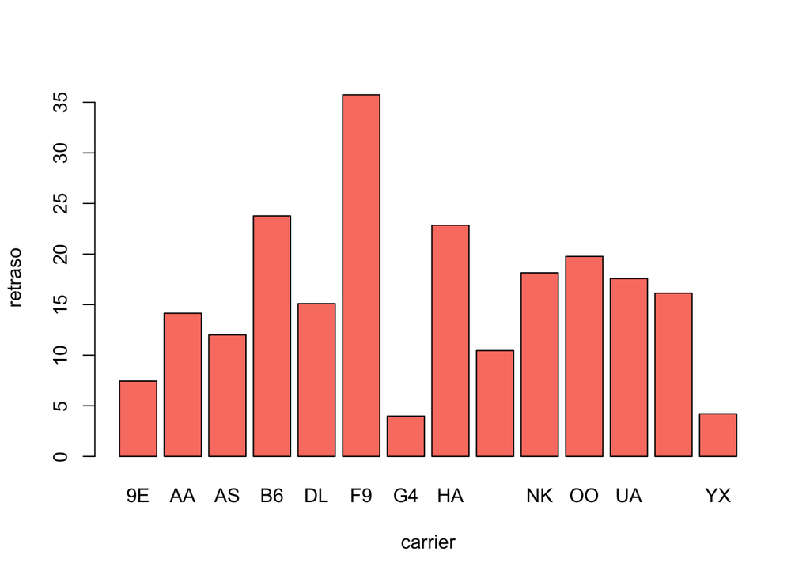

```r
barplot(retraso ~ carrier, data=media_retraso, col="salmon")
```

# 4 Ejercicios

1. Encuentre todos los vuelos que:
   1. se retarden más de 2 horas en la llegada. (arrival delay)
   2. volaron a Houston, ya sea a IAH o HOU.
   3. fueron operados por United, American o Delta.
   4. salieron en Julio, Agosto y Septiembre.
   5. llegaron más de dos horas tarde y salieron a tiempo.
   6. salieron demorados por al menos una hora.
   7. salieron entre medianoche y las 6am.
2. Ordene el `dataframe` flights para encontrar los vuelos que salen más demorados.
3. ¿Qué vuelos son los más largos?
4. ¿Los más cortos?

# 5 Solución

**Código**

```r
uno <-  filter(flights, arr_delay >= 120)
uno <- select(uno, month,day,carrier,arr_delay)
head(uno)
```

| month | day | carrier | arr_delay |
| --- | --- | --- | --- |
| 1 | 1 | UA | 205 |
| 1 | 1 | B6 | 166 |
| 1 | 1 | UA | 211 |
| 1 | 1 | DL | 126 |
| 1 | 1 | UA | 129 |
| 1 | 1 | UA | 183 |

**Código**

```r
dos <- filter(flights, dest=="IAH" | dest=="HOU")
head(dos)
```

| year | month | day | dep_time | sched_dep_time | dep_delay | arr_time | sched_arr_time | arr_delay | carrier | flight | tailnum | origin | dest | air_time | distance | hour | minute | time_hour |
| --- | --- | --- | --- | --- | --- | --- | --- | --- | --- | --- | --- | --- | --- | --- | --- | --- | --- | --- |
| 2023 | 1 | 1 | 537 | 520 | 17 | 926 | 818 | 68 | UA | 206 | N13113 | EWR | IAH | 258 | 1400 | 5 | 20 | 2023-01-01 05:00:00 |
| 2023 | 1 | 1 | 605 | 605 | 0 | 857 | 915 | -18 | WN | 844 | N965WN | LGA | HOU | 214 | 1428 | 6 | 5 | 2023-01-01 06:00:00 |
| 2023 | 1 | 1 | 727 | 729 | -2 | 1024 | 1041 | -17 | UA | 976 | N73256 | LGA | IAH | 208 | 1416 | 7 | 29 | 2023-01-01 07:00:00 |
| 2023 | 1 | 1 | 734 | 735 | -1 | 1016 | 1051 | -35 | UA | 308 | N76065 | EWR | IAH | 195 | 1400 | 7 | 35 | 2023-01-01 07:00:00 |
| 2023 | 1 | 1 | 837 | 835 | 2 | 1123 | 1209 | -46 | DL | 828 | N135DQ | LGA | IAH | 202 | 1416 | 8 | 35 | 2023-01-01 08:00:00 |
| 2023 | 1 | 1 | 1112 | 1100 | 12 | 1348 | 1420 | -32 | UA | 130 | N77259 | EWR | IAH | 190 | 1400 | 11 | 0 | 2023-01-01 11:00:00 |

**Código**

```r
nrow(dos)
```

```
[1] 8667
```

**Código**

```r
tres <- filter(flights, carrier %in% c("AA", "DL", "UA"))
head(tres)
```

| year | month | day | dep_time | sched_dep_time | dep_delay | arr_time | sched_arr_time | arr_delay | carrier | flight | tailnum | origin | dest | air_time | distance | hour | minute | time_hour |
| --- | --- | --- | --- | --- | --- | --- | --- | --- | --- | --- | --- | --- | --- | --- | --- | --- | --- | --- |
| 2023 | 1 | 1 | 1 | 2038 | 203 | 328 | 3 | 205 | UA | 628 | N25201 | EWR | SMF | 367 | 2500 | 20 | 38 | 2023-01-01 20:00:00 |
| 2023 | 1 | 1 | 18 | 2300 | 78 | 228 | 135 | 53 | DL | 393 | N830DN | JFK | ATL | 108 | 760 | 23 | 0 | 2023-01-01 23:00:00 |
| 2023 | 1 | 1 | 36 | 2048 | 228 | 223 | 2252 | 211 | UA | 219 | N17730 | EWR | DTW | 80 | 488 | 20 | 48 | 2023-01-01 20:00:00 |
| 2023 | 1 | 1 | 503 | 500 | 3 | 808 | 815 | -7 | AA | 499 | N925AN | EWR | MIA | 154 | 1085 | 5 | 0 | 2023-01-01 05:00:00 |
| 2023 | 1 | 1 | 524 | 530 | -6 | 645 | 710 | -25 | AA | 981 | N918AN | EWR | ORD | 119 | 719 | 5 | 30 | 2023-01-01 05:00:00 |
| 2023 | 1 | 1 | 537 | 520 | 17 | 926 | 818 | 68 | UA | 206 | N13113 | EWR | IAH | 258 | 1400 | 5 | 20 | 2023-01-01 05:00:00 |

**Código**

```r
nrow(tres)
```

```
[1] 181728
```

**Código**

```r
cuatro <- filter(flights, month >= 7, month <= 9)
head(cuatro)
```

| year | month | day | dep_time | sched_dep_time | dep_delay | arr_time | sched_arr_time | arr_delay | carrier | flight | tailnum | origin | dest | air_time | distance | hour | minute | time_hour |
| --- | --- | --- | --- | --- | --- | --- | --- | --- | --- | --- | --- | --- | --- | --- | --- | --- | --- | --- |
| 2023 | 7 | 1 | 2 | 2256 | 66 | 401 | 300 | 61 | B6 | 256 | N534JB | JFK | PSE | 199 | 1617 | 22 | 56 | 2023-07-01 22:00:00 |
| 2023 | 7 | 1 | 49 | 2106 | 223 | 256 | 2338 | 198 | UA | 224 | N27269 | EWR | LAS | 284 | 2227 | 21 | 6 | 2023-07-01 21:00:00 |
| 2023 | 7 | 1 | 200 | 2135 | 265 | 423 | 20 | 243 | B6 | 76 | N190JB | JFK | MCO | 123 | 944 | 21 | 35 | 2023-07-01 21:00:00 |
| 2023 | 7 | 1 | 457 | 500 | -3 | 741 | 808 | -27 | AA | 352 | N933NN | EWR | MIA | 136 | 1085 | 5 | 0 | 2023-07-01 05:00:00 |
| 2023 | 7 | 1 | 457 | 500 | -3 | 743 | 812 | -29 | NK | 253 | N952NK | EWR | OAK | 329 | 2555 | 5 | 0 | 2023-07-01 05:00:00 |
| 2023 | 7 | 1 | 459 | 500 | -1 | 640 | 658 | -18 | AA | 744 | N152UW | EWR | CLT | 73 | 529 | 5 | 0 | 2023-07-01 05:00:00 |

**Código**

```r
cinco <- filter(flights, arr_delay > 120, dep_delay <= 0)
head(cinco)
```

| year | month | day | dep_time | sched_dep_time | dep_delay | arr_time | sched_arr_time | arr_delay | carrier | flight | tailnum | origin | dest | air_time | distance | hour | minute | time_hour |
| --- | --- | --- | --- | --- | --- | --- | --- | --- | --- | --- | --- | --- | --- | --- | --- | --- | --- | --- |
| 2023 | 1 | 31 | 925 | 930 | -5 | 1301 | 1059 | 122 | YX | 1773 | N234JQ | JFK | DCA | 68 | 213 | 9 | 30 | 2023-01-31 09:00:00 |
| 2023 | 2 | 1 | 827 | 830 | -3 | 1226 | 1020 | 126 | B6 | 399 | N323JB | JFK | BNA | 143 | 765 | 8 | 30 | 2023-02-01 08:00:00 |
| 2023 | 2 | 23 | 725 | 729 | -4 | 1118 | 856 | 142 | YX | 1152 | N979RP | EWR | BUF | 59 | 282 | 7 | 29 | 2023-02-23 07:00:00 |
| 2023 | 3 | 14 | 1349 | 1350 | -1 | 1830 | 1627 | 123 | 9E | 1464 | N907XJ | LGA | JAX | 123 | 833 | 13 | 50 | 2023-03-14 13:00:00 |
| 2023 | 4 | 1 | 827 | 830 | -3 | 1333 | 1122 | 131 | 9E | 1342 | N184GJ | JFK | JAX | 122 | 828 | 8 | 30 | 2023-04-01 08:00:00 |
| 2023 | 4 | 5 | 729 | 729 | 0 | 1244 | 1034 | 130 | AA | 159 | N906AN | LGA | DFW | 302 | 1389 | 7 | 29 | 2023-04-05 07:00:00 |

**Código**

```r
seis <- filter(flights, dep_delay >= 60)
head(seis)
```

| year | month | day | dep_time | sched_dep_time | dep_delay | arr_time | sched_arr_time | arr_delay | carrier | flight | tailnum | origin | dest | air_time | distance | hour | minute | time_hour |
| --- | --- | --- | --- | --- | --- | --- | --- | --- | --- | --- | --- | --- | --- | --- | --- | --- | --- | --- |
| 2023 | 1 | 1 | 1 | 2038 | 203 | 328 | 3 | 205 | UA | 628 | N25201 | EWR | SMF | 367 | 2500 | 20 | 38 | 2023-01-01 20:00:00 |
| 2023 | 1 | 1 | 18 | 2300 | 78 | 228 | 135 | 53 | DL | 393 | N830DN | JFK | ATL | 108 | 760 | 23 | 0 | 2023-01-01 23:00:00 |
| 2023 | 1 | 1 | 33 | 2140 | 173 | 238 | 2352 | 166 | B6 | 1053 | N265JB | JFK | CHS | 108 | 636 | 21 | 40 | 2023-01-01 21:00:00 |
| 2023 | 1 | 1 | 36 | 2048 | 228 | 223 | 2252 | 211 | UA | 219 | N17730 | EWR | DTW | 80 | 488 | 20 | 48 | 2023-01-01 20:00:00 |
| 2023 | 1 | 1 | 705 | 601 | 64 | 809 | 720 | 49 | UA | 509 | N818UA | EWR | IAD | 44 | 212 | 6 | 1 | 2023-01-01 06:00:00 |
| 2023 | 1 | 1 | 819 | 659 | 80 | 950 | 840 | 70 | AA | 1086 | N943NN | EWR | ORD | 121 | 719 | 6 | 59 | 2023-01-01 06:00:00 |

**Código**

```r
summary(flights$dep_time)
```

```
   Min. 1st Qu.  Median    Mean 3rd Qu.    Max.    NA's
      1     931    1357    1366    1804    2400   10738
```

**Código**

```r
siete <- filter(flights, dep_time <= 600 | dep_time == 2400)
head(siete)
```

| year | month | day | dep_time | sched_dep_time | dep_delay | arr_time | sched_arr_time | arr_delay | carrier | flight | tailnum | origin | dest | air_time | distance | hour | minute | time_hour |
| --- | --- | --- | --- | --- | --- | --- | --- | --- | --- | --- | --- | --- | --- | --- | --- | --- | --- | --- |
| 2023 | 1 | 1 | 1 | 2038 | 203 | 328 | 3 | 205 | UA | 628 | N25201 | EWR | SMF | 367 | 2500 | 20 | 38 | 2023-01-01 20:00:00 |
| 2023 | 1 | 1 | 18 | 2300 | 78 | 228 | 135 | 53 | DL | 393 | N830DN | JFK | ATL | 108 | 760 | 23 | 0 | 2023-01-01 23:00:00 |
| 2023 | 1 | 1 | 31 | 2344 | 47 | 500 | 426 | 34 | B6 | 371 | N807JB | JFK | BQN | 190 | 1576 | 23 | 44 | 2023-01-01 23:00:00 |
| 2023 | 1 | 1 | 33 | 2140 | 173 | 238 | 2352 | 166 | B6 | 1053 | N265JB | JFK | CHS | 108 | 636 | 21 | 40 | 2023-01-01 21:00:00 |
| 2023 | 1 | 1 | 36 | 2048 | 228 | 223 | 2252 | 211 | UA | 219 | N17730 | EWR | DTW | 80 | 488 | 20 | 48 | 2023-01-01 20:00:00 |
| 2023 | 1 | 1 | 503 | 500 | 3 | 808 | 815 | -7 | AA | 499 | N925AN | EWR | MIA | 154 | 1085 | 5 | 0 | 2023-01-01 05:00:00 |

**Código**

```r
nrow(siete)
```

```
[1] 13589
```

## 5.1 Ordene el `dataframe` flights para encontrar los vuelos que salen más demorados.

**Código**

```r
head(arrange(flights, desc(dep_delay)))
```

| year | month | day | dep_time | sched_dep_time | dep_delay | arr_time | sched_arr_time | arr_delay | carrier | flight | tailnum | origin | dest | air_time | distance | hour | minute | time_hour |
| --- | --- | --- | --- | --- | --- | --- | --- | --- | --- | --- | --- | --- | --- | --- | --- | --- | --- | --- |
| 2023 | 12 | 17 | 1953 | 1340 | 1813 | 2155 | 1543 | 1812 | AA | 645 | N195UW | EWR | CLT | 86 | 529 | 13 | 40 | 2023-12-17 13:00:00 |
| 2023 | 10 | 1 | 1240 | 659 | 1781 | 1407 | 835 | 1772 | AA | 992 | N958NN | EWR | ORD | 102 | 719 | 6 | 59 | 2023-10-01 06:00:00 |
| 2023 | 4 | 25 | 1201 | 659 | 1742 | 1315 | 818 | 1737 | AA | 518 | N808AW | LGA | DCA | 42 | 214 | 6 | 59 | 2023-04-25 06:00:00 |
| 2023 | 2 | 7 | 2045 | 1700 | 1665 | 2352 | 2025 | 1647 | AA | 600 | N967AN | LGA | DFW | 223 | 1389 | 17 | 0 | 2023-02-07 17:00:00 |
| 2023 | 4 | 20 | 926 | 619 | 1627 | 1135 | 822 | 1633 | AA | 322 | N153UW | JFK | CLT | 80 | 541 | 6 | 19 | 2023-04-20 06:00:00 |
| 2023 | 10 | 29 | 856 | 600 | 1616 | 1050 | 805 | 1605 | AA | 215 | N162UW | LGA | CLT | 87 | 544 | 6 | 0 | 2023-10-29 06:00:00 |

## 5.2 Vuelos más cortos y más largos en tiempo

**Código**

```r
head(arrange(flights, air_time))
```

| year | month | day | dep_time | sched_dep_time | dep_delay | arr_time | sched_arr_time | arr_delay | carrier | flight | tailnum | origin | dest | air_time | distance | hour | minute | time_hour |
| --- | --- | --- | --- | --- | --- | --- | --- | --- | --- | --- | --- | --- | --- | --- | --- | --- | --- | --- |
| 2023 | 1 | 12 | 2151 | 2155 | -4 | 2247 | 2256 | -9 | YX | 1737 | N225JQ | LGA | BDL | 18 | 101 | 21 | 55 | 2023-01-12 21:00:00 |
| 2023 | 1 | 3 | 1155 | 1200 | -5 | 1235 | 1311 | -36 | 9E | 1561 | N331PQ | LGA | BDL | 19 | 101 | 12 | 0 | 2023-01-03 12:00:00 |
| 2023 | 1 | 12 | 1452 | 1455 | -3 | 1540 | 1607 | -27 | YX | 1812 | N860RW | LGA | BDL | 19 | 101 | 14 | 55 | 2023-01-12 14:00:00 |
| 2023 | 1 | 15 | 757 | 759 | -2 | 839 | 900 | -21 | YX | 1183 | N725YX | EWR | PHL | 19 | 80 | 7 | 59 | 2023-01-15 07:00:00 |
| 2023 | 1 | 19 | 1450 | 1455 | -5 | 1536 | 1607 | -31 | YX | 1812 | N879RW | LGA | BDL | 19 | 101 | 14 | 55 | 2023-01-19 14:00:00 |
| 2023 | 2 | 5 | 1422 | 1430 | -8 | 1511 | 1538 | -27 | YX | 1546 | N815MD | LGA | BDL | 19 | 101 | 14 | 30 | 2023-02-05 14:00:00 |

**Código**

```r
head(arrange(flights, desc(air_time)))
```

| year | month | day | dep_time | sched_dep_time | dep_delay | arr_time | sched_arr_time | arr_delay | carrier | flight | tailnum | origin | dest | air_time | distance | hour | minute | time_hour |
| --- | --- | --- | --- | --- | --- | --- | --- | --- | --- | --- | --- | --- | --- | --- | --- | --- | --- | --- |
| 2023 | 3 | 9 | 1009 | 1000 | 9 | 1720 | 1605 | 75 | HA | 22 | N381HA | JFK | HNL | 701 | 4983 | 10 | 0 | 2023-03-09 10:00:00 |
| 2023 | 1 | 10 | 913 | 900 | 13 | 1615 | 1525 | 50 | DL | 101 | N838MH | JFK | HNL | 695 | 4983 | 9 | 0 | 2023-01-10 09:00:00 |
| 2023 | 3 | 10 | 852 | 900 | -8 | 1616 | 1537 | 39 | DL | 101 | N175DN | JFK | HNL | 695 | 4983 | 9 | 0 | 2023-03-10 09:00:00 |
| 2023 | 3 | 8 | 853 | 900 | -7 | 1608 | 1525 | 43 | DL | 101 | N177DN | JFK | HNL | 692 | 4983 | 9 | 0 | 2023-03-08 09:00:00 |
| 2023 | 1 | 31 | 858 | 900 | -2 | 1627 | 1525 | 62 | DL | 101 | N843MH | JFK | HNL | 688 | 4983 | 9 | 0 | 2023-01-31 09:00:00 |
| 2023 | 4 | 2 | 1104 | 1000 | 64 | 1702 | 1510 | 112 | HA | 22 | N392HA | JFK | HNL | 686 | 4983 | 10 | 0 | 2023-04-02 10:00:00 |

## 5.3 Vuelos más rápidos (en velocidad)

**Código**

```r
flights <- mutate(flights, speed=distance/air_time, na.rm=TRUE)
head(arrange(flights,desc(speed)))
```

| year | month | day | dep_time | sched_dep_time | dep_delay | arr_time | sched_arr_time | arr_delay | carrier | flight | tailnum | origin | dest | air_time | distance | hour | minute | time_hour | speed | na.rm |
| --- | --- | --- | --- | --- | --- | --- | --- | --- | --- | --- | --- | --- | --- | --- | --- | --- | --- | --- | --- | --- |
| 2023 | 12 | 24 | 1454 | 1405 | 49 | 1850 | 1535 | 195 | WN | 680 | N7875A | LGA | MDW | 54 | 725 | 14 | 5 | 2023-12-24 14:00:00 | 13.425926 | TRUE |
| 2023 | 4 | 5 | 1529 | 1500 | 29 | 1742 | 1725 | 17 | 9E | 1261 | N293PQ | JFK | CHS | 53 | 636 | 15 | 0 | 2023-04-05 15:00:00 | 12.000000 | TRUE |
| 2023 | 4 | 15 | 1109 | 1112 | -3 | 1351 | 1429 | -38 | DL | 568 | N127DN | LGA | MIA | 97 | 1096 | 11 | 12 | 2023-04-15 11:00:00 | 11.298969 | TRUE |
| 2023 | 5 | 5 | 1952 | 1859 | 53 | 2134 | 2124 | 10 | DL | 808 | N389DA | EWR | ATL | 69 | 746 | 18 | 59 | 2023-05-05 18:00:00 | 10.811594 | TRUE |
| 2023 | 7 | 14 | 2127 | 1859 | 148 | 19 | 2144 | 155 | DL | 191 | N379DN | LGA | ATL | 73 | 762 | 18 | 59 | 2023-07-14 18:00:00 | 10.438356 | TRUE |
| 2023 | 2 | 1 | 721 | 715 | 6 | 1100 | 900 | 120 | WN | 965 | N8777Q | LGA | BNA | 79 | 764 | 7 | 15 | 2023-02-01 07:00:00 | 9.670886 | TRUE |

## 5.4 Vuelos más cortos y más largos en distancia

**Código**

```r
head(arrange(flights, desc(distance)))
```

| year | month | day | dep_time | sched_dep_time | dep_delay | arr_time | sched_arr_time | arr_delay | carrier | flight | tailnum | origin | dest | air_time | distance | hour | minute | time_hour | speed | na.rm |
| --- | --- | --- | --- | --- | --- | --- | --- | --- | --- | --- | --- | --- | --- | --- | --- | --- | --- | --- | --- | --- |
| 2023 | 1 | 1 | 949 | 900 | 49 | NA | 1525 | NA | DL | 101 | N176DN | JFK | HNL | NA | 4983 | 9 | 0 | 2023-01-01 09:00:00 | NA | TRUE |
| 2023 | 1 | 1 | 1023 | 1000 | 23 | 1637 | 1610 | 27 | HA | 22 | N396HA | JFK | HNL | 636 | 4983 | 10 | 0 | 2023-01-01 10:00:00 | 7.834906 | TRUE |
| 2023 | 1 | 2 | 919 | 900 | 19 | 1543 | 1525 | 18 | DL | 101 | N176DN | JFK | HNL | 657 | 4983 | 9 | 0 | 2023-01-02 09:00:00 | 7.584475 | TRUE |
| 2023 | 1 | 2 | 951 | 1000 | -9 | 1620 | 1610 | 10 | HA | 22 | N389HA | JFK | HNL | 651 | 4983 | 10 | 0 | 2023-01-02 10:00:00 | 7.654378 | TRUE |
| 2023 | 1 | 3 | 922 | 900 | 22 | 1535 | 1525 | 10 | DL | 101 | N179DN | JFK | HNL | 652 | 4983 | 9 | 0 | 2023-01-03 09:00:00 | 7.642638 | TRUE |
| 2023 | 1 | 3 | 1007 | 1000 | 7 | 1630 | 1610 | 20 | HA | 22 | N388HA | JFK | HNL | 650 | 4983 | 10 | 0 | 2023-01-03 10:00:00 | 7.666154 | TRUE |

**Código**

```r
head(arrange(flights, distance))
```

| year | month | day | dep_time | sched_dep_time | dep_delay | arr_time | sched_arr_time | arr_delay | carrier | flight | tailnum | origin | dest | air_time | distance | hour | minute | time_hour | speed | na.rm |
| --- | --- | --- | --- | --- | --- | --- | --- | --- | --- | --- | --- | --- | --- | --- | --- | --- | --- | --- | --- | --- |
| 2023 | 1 | 1 | 816 | 820 | -4 | 910 | 921 | -11 | YX | 1176 | N730YX | EWR | PHL | 31 | 80 | 8 | 20 | 2023-01-01 08:00:00 | 2.580645 | TRUE |
| 2023 | 1 | 2 | 820 | 820 | 0 | 907 | 921 | -14 | YX | 1176 | N642RW | EWR | PHL | 25 | 80 | 8 | 20 | 2023-01-02 08:00:00 | 3.200000 | TRUE |
| 2023 | 1 | 2 | 2324 | 2159 | 85 | 41 | 2300 | 101 | UA | 534 | N27252 | EWR | PHL | 29 | 80 | 21 | 59 | 2023-01-02 21:00:00 | 2.758621 | TRUE |
| 2023 | 1 | 3 | 14 | 2158 | 136 | 104 | 2259 | 125 | UA | 534 | N23707 | EWR | PHL | 27 | 80 | 21 | 58 | 2023-01-03 21:00:00 | 2.962963 | TRUE |
| 2023 | 1 | 3 | 815 | 820 | -5 | 913 | 921 | -8 | YX | 1176 | N653RW | EWR | PHL | 29 | 80 | 8 | 20 | 2023-01-03 08:00:00 | 2.758621 | TRUE |
| 2023 | 1 | 4 | 756 | 759 | -3 | 903 | 900 | 3 | YX | 1183 | N657RW | EWR | PHL | 28 | 80 | 7 | 59 | 2023-01-04 07:00:00 | 2.857143 | TRUE |

# 6 Uso de `pipes`

**Código**

```r
log(8)
```

```
[1] 2.079442
```

**Código**

```r
8 %>% log()
```

```
[1] 2.079442
```

**Código**

```r
sin(cos(log(5)))
```

```
[1] -0.03862236
```

**Código**

```r
5 %>% log() %>% cos() %>% sin()
```

```
[1] -0.03862236
```

Vea los primeros comandos, se pudieron haber escrito:

```
flights %>% as_tibble()
flights %>% str()
flights %>% filter( month ==12, day == 1)
dframe <- flights %>% select(month, day) %>% filter(distance < 500)
```

atajo de teclado: `%>%` control/command shift m